# Лабораторная работа №7

Анализ файловой системы Linux. Команды для работы с файлами и каталогами

Прозорова Е. Е.

Российский университет дружбы народов, Москва, Россия

20 марта 2025

# Информация

## Докладчик

- Прозорова Елизавета Евгеньевна
- студент факультета ФМиЕН
- группа НММбд-03-24
- Российский университет дружбы народов
- 1132246767@pfur.ru

# Вводная часть

## Цели и задачи

- Ознакомление с файловой системой Linux, её структурой, именами и содержанием каталогов.
- Приобретение практических навыков по применению команд для работы с файлами и каталогами, по управлению процессами (и работами), по проверке использования диска и обслуживанию файловой системы

# Выполнение лабораторной работы

## Копирование файлов и каталогов

Я выполнила команды на копирование файлов и каталогов.

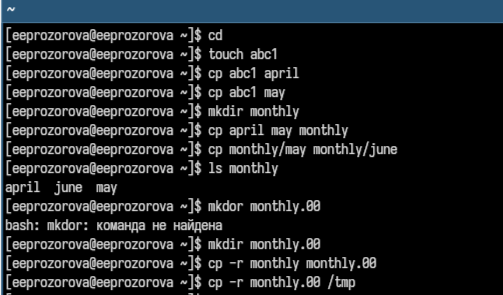

Копирование файлов и каталогов

## Перемещение файлов и каталогов

Я выполнила команды на перемещение и переименование файлов и каталогов.

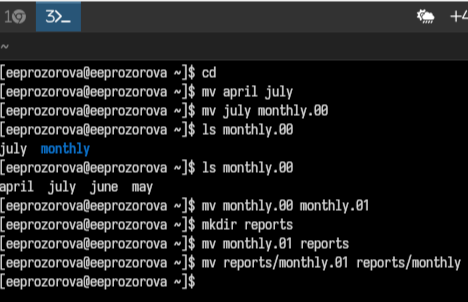

Перемещение файлов и каталогов

## Права доступа файла may

Я выполнила команды на изменение прав доступ. Я создала файл с правом выполнения для владельца, затем лишила этот файл этого права.

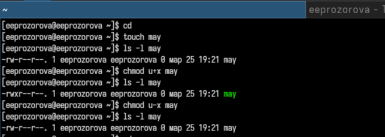

Права доступа файла may

## mouthly

Я создала каталог monthly с запретом на чтение для членов группы и всех остальных пользователей:

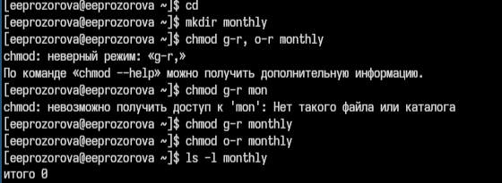

mouthly

## Создание файла ~/abc1 с правом записи для членов группы.

Я создала файл ~/abc1 с правом записи для членов группы.

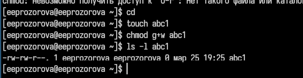

abc1

## mount

Я выполнила команды на анализ файловой системы. Сначало я попробовала команду mount.

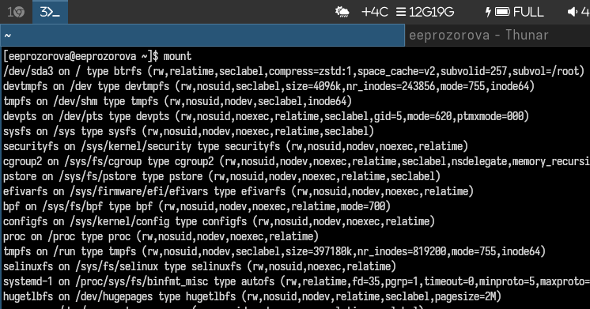

mount

## Команда cat

Затем я ввела команду для просмотра файла /etc/fstab.

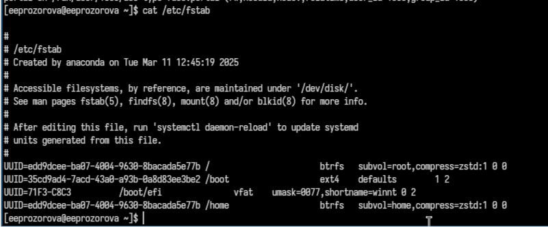

Команда cat

## Команда df

Команда для определения объёма свободного пространства на файловой системе.

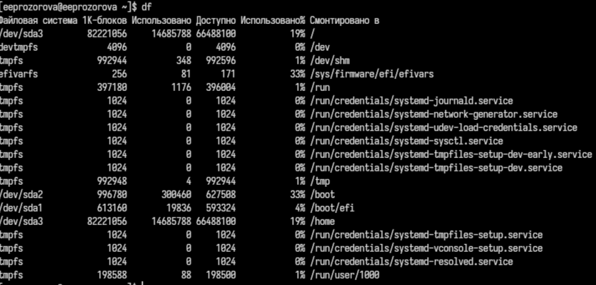

Команда df

## fsck

Команда для проверки (а в ряде случаев восстановления) целостности файловой системы:

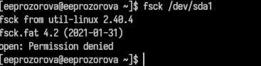

fsck

## Я выполнила следующие команды.

Я скопировала файл /usr/include/sys/io.h в домашний каталог. Создала каталог ski.plases и переместила файл equipment в ski.plases

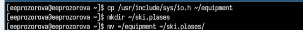

Перемещение файла equipment в ski.plases

## Переименование файла equipment в equiplist

Переименовала файла equipment в equiplist

[figure not shown]

## Файл abc1]

Создала файла abc1 и скопировала его в ski.plases как equiplist2

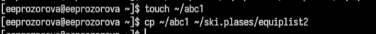

Файл abc1

## Каталог equipment

Создала каталога equipment в ski.plases и переместила equiplist и equiplist2 в каталог equipment

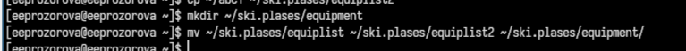

Каталог equipment

Затем я создала и перемеместила каталога newdir в ski.plases с новым именем plans

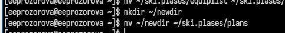

Новый каталог plans

## Присвоение прав доступа

Теперь я присвоила перечисленным файлам права доступа (файлы создала заранее)

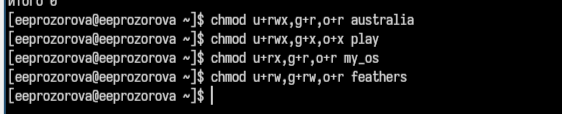

Присвоение прав доступа

## Использование команды cat

Я просмотрела содержимое файла /etc/passwd

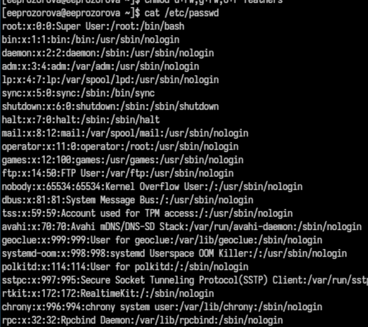

Использование команды cat

Я скопировала файл ~/feathers в файл ~/file.old.

Переместила файл ~/file.old в каталог ~/play, скопировала каталог ~/play в каталог ~/fun и переместила каталог ~/fun в каталог ~/play и назвала его games.

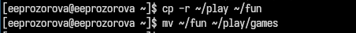

Работа с каталогом play

Я лишила себя права на чтение файла ~/feathers и попробовала несколько команд на проверку. Когда я убедилась, я вернула права.

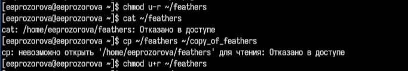

Лишение прав на чтение файлов

Лишила себя права на выполнение каталога ~/play, посмотрела как это работает и вернула права обратно.

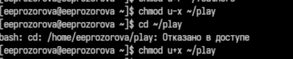

Лишение прав на выполнение каталога

## Просмотр mount, fsck, mkfs, kill.

Затем я прочитала man по командам mount, fsck, mkfs, kill.

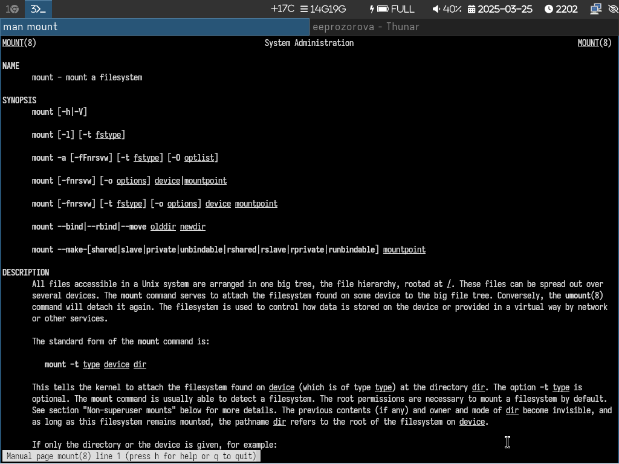

Просмотр mount

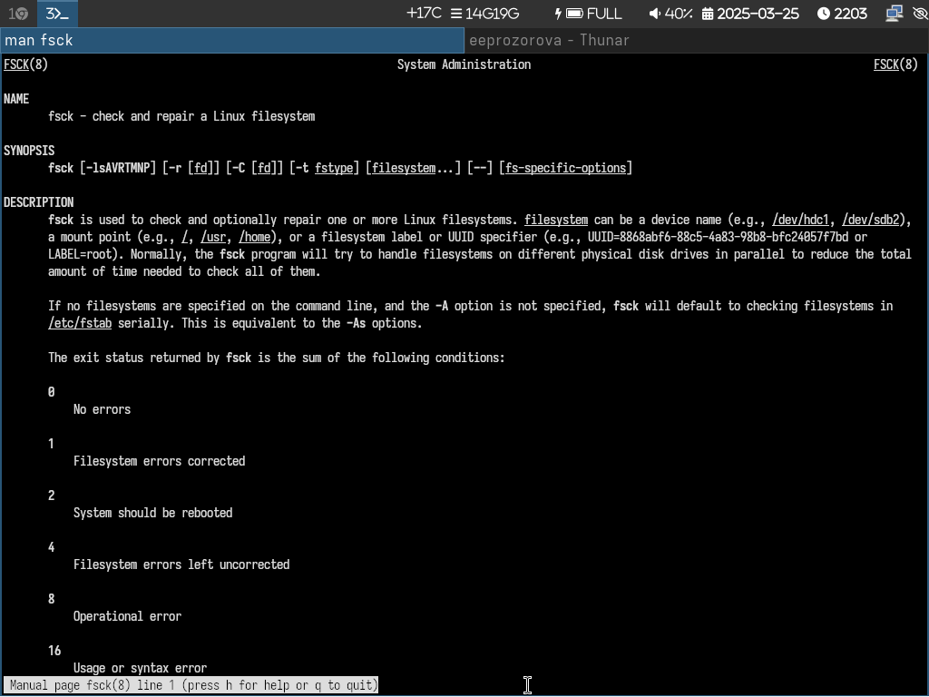

Просмотр fsck

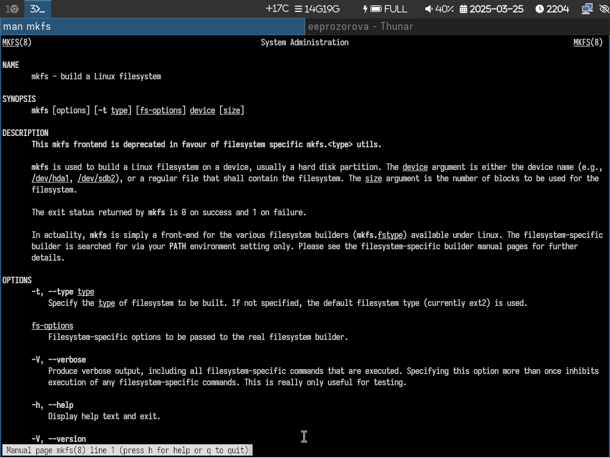

Просмотр mkfs

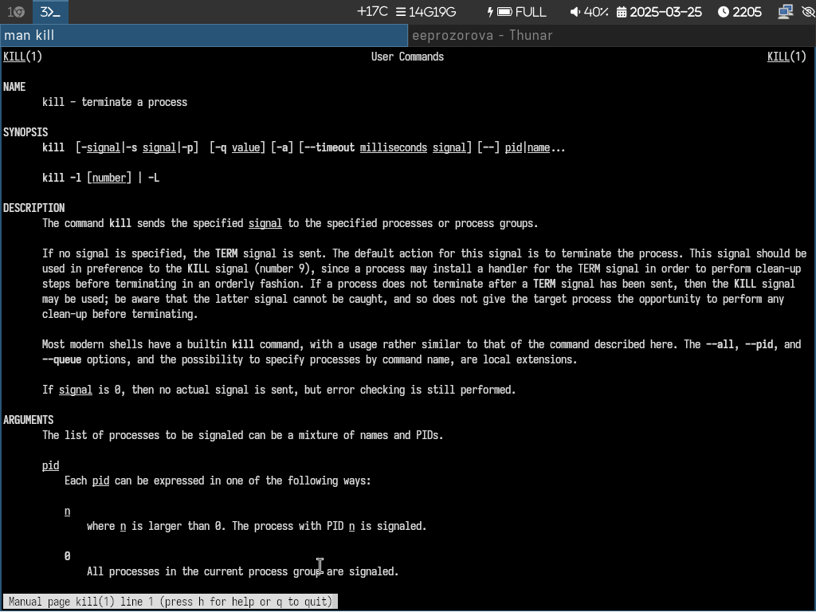

Просмотр kill

# Выводы

Я ознакомилась с файловой системой Linux, её структурой, именами и содержанием каталогов приобрела практические навыки по применению команд для работы с файлами и каталогами, по управлению процессами (и работами), по проверке использования диска и обслуживанию файловой системы.